# Time Series Analysis

```python
import yfinance as yf
import matplotlib.pyplot as plt
stock_data = yf.download('AAPL',start = '2024-01-01')
stock_data.head(10)
```

```
[*********************100%***********************]  1 of 1 completed
```

| Price Ticker Date | Close AAPL | High AAPL | Low AAPL | Open AAPL | Volume AAPL |
| --- | --- | --- | --- | --- | --- |
| 2024-01-02 | 183.404022 | 186.170300 | 181.675100 | 184.895829 | 82488700 |
| 2024-01-03 | 182.030746 | 183.641118 | 181.220616 | 182.001109 | 58414500 |
| 2024-01-04 | 179.718964 | 180.884744 | 178.701371 | 179.956063 | 71983600 |
| 2024-01-05 | 178.997726 | 180.558698 | 177.999897 | 179.797983 | 62379700 |
| 2024-01-08 | 183.324997 | 183.364524 | 179.313901 | 179.896791 | 59144500 |
| 2024-01-09 | 182.910019 | 182.919893 | 180.529043 | 181.704712 | 42841800 |
| 2024-01-10 | 183.947388 | 184.154850 | 181.704725 | 182.129554 | 46792900 |
| 2024-01-11 | 183.354614 | 184.797036 | 181.408341 | 184.293169 | 49128400 |
| 2024-01-12 | 183.680618 | 184.490749 | 182.959415 | 183.818931 | 40477800 |
| 2024-01-16 | 181.418228 | 182.040630 | 178.750737 | 179.965933 | 65603000 |

```python
stock_data.shape
```

[output not shown]

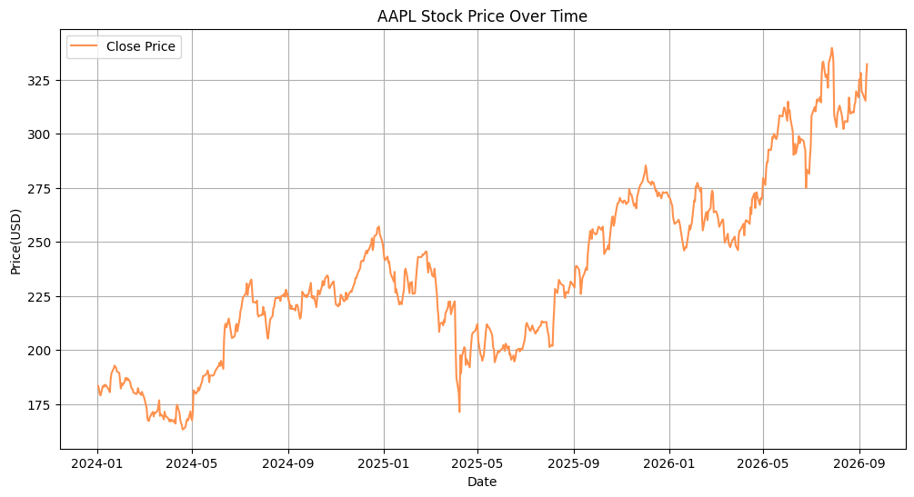

```python
plt.figure(figsize=(12,6))
plt.plot(stock_data.index, stock_data['Close'],label="Close Price",color="#FF914D")
plt.title('AAPL Stock Price Over Time')
plt.xlabel("Date")
plt.ylabel('Price(USD)')
plt.legend()
plt.grid(True)
plt.show
```

Classical Time Series Decomposition - Additive

```python
from statsmodels.tsa.seasonal import seasonal_decompose
decomposition_additive = seasonal_decompose(stock_data['Close'], model='additive',period=30)
```

```python
trend_additive = decomposition_additive.trend
seasonal_additive = decomposition_additive.seasonal
residual_additive = decomposition_additive.resid
```

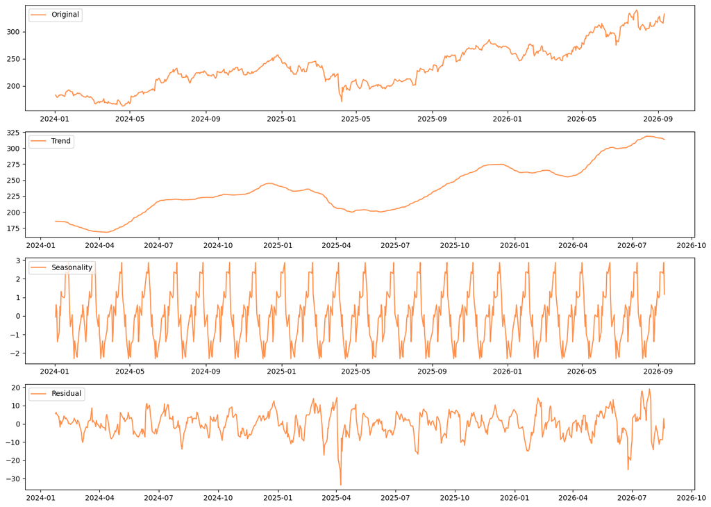

```python
plt.figure(figsize =(14,10))
plt.subplot(411)
plt.plot(stock_data['Close'],label="Original",color="#FF914D")
plt.legend(loc="upper left")
plt.subplot(412)
plt.plot(trend_additive,label="Trend",color="#FF914D")
plt.legend(loc="upper left")
plt.subplot(413)
plt.plot(seasonal_additive,label="Seasonality",color="#FF914D")
plt.legend(loc="upper left")
plt.subplot(414)
plt.plot(residual_additive,label="Residual",color="#FF914D")
plt.legend(loc='upper left')
plt.tight_layout()
plt.show()
```

Classical Time Series Decomposition - Multiplicative

```python
decomposition_multiplicative = seasonal_decompose(stock_data['Close'], model='multiplicative',period=30)
```

```python
trend_multiplicative = decomposition_multiplicative.trend
seasonal_multiplicative = decomposition_multiplicative.seasonal
residual_multiplicative = decomposition_multiplicative.resid
```

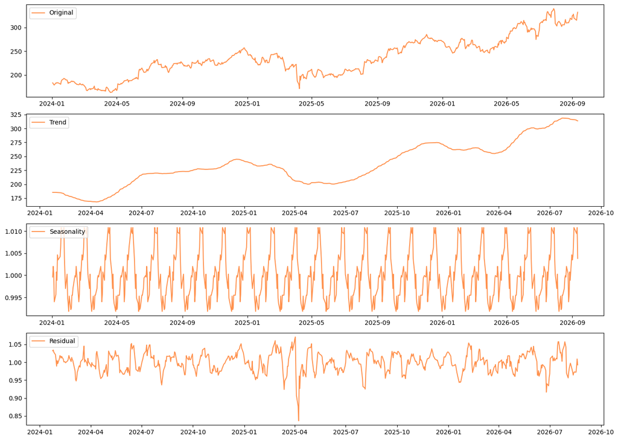

```python
plt.figure(figsize =(14,10))
plt.subplot(411)
plt.plot(stock_data['Close'],label="Original",color="#FF914D")
plt.legend(loc="upper left")
plt.subplot(412)
plt.plot(trend_multiplicative,label="Trend",color="#FF914D")
plt.legend(loc="upper left")
plt.subplot(413)
plt.plot(seasonal_multiplicative,label="Seasonality",color="#FF914D")
plt.legend(loc="upper left")
plt.subplot(414)
plt.plot(residual_multiplicative,label="Residual",color="#FF914D")
plt.legend(loc='upper left')
plt.tight_layout()
plt.show()
```

```python
seasonal_multiplicative
```

```
Date
2024-01-02    0.999606
2024-01-03    1.002033
2024-01-04    1.000391
2024-01-05    0.993991
2024-01-08    0.995631
                ...
2026-09-04    1.010850
2026-09-08    1.009780
2026-09-09    1.009475
2026-09-10    1.010842
2026-09-11    1.003827
Name: seasonal, Length: 676, dtype: float64
```

```python
seasonal_additive
```

```
Date
2024-01-02   -0.057547
2024-01-03    0.600540
2024-01-04    0.284337
2024-01-05   -1.390566
2024-01-08   -0.866912
                ...
2026-09-04    2.369484
2026-09-08    2.348631
2026-09-09    2.288618
2026-09-10    2.877731
2026-09-11    1.166388
Name: seasonal, Length: 676, dtype: float64
```

```python
#how to determine which is better?
```

STL using LOESS  
Classical assumed fixed seasonal pattern, also very susceptible to outliers,  
stl shows the actual pattern which may or may not vary over time, loess can handle outliers but it can only handle additive model

```python
stock_data['Close']
```

| Ticker Date | AAPL |
| --- | --- |
| 2024-01-02 | 183.404022 |
| 2024-01-03 | 182.030746 |
| 2024-01-04 | 179.718948 |
| 2024-01-05 | 178.997726 |
| 2024-01-08 | 183.324982 |
| ... | ... |
| 2026-09-04 | 319.970001 |
| 2026-09-08 | 316.220001 |
| 2026-09-09 | 315.339996 |
| 2026-09-10 | 326.570007 |
| 2026-09-11 | 332.269989 |

676 rows × 1 columns

```python
endog = stock_data['Close'].squeeze()
endog
```

```
Date
2024-01-02    183.404022
2024-01-03    182.030746
2024-01-04    179.718948
2024-01-05    178.997726
2024-01-08    183.324982
                 ...
2026-09-04    319.970001
2026-09-08    316.220001
2026-09-09    315.339996
2026-09-10    326.570007
2026-09-11    332.269989
Name: AAPL, Length: 676, dtype: float64
```

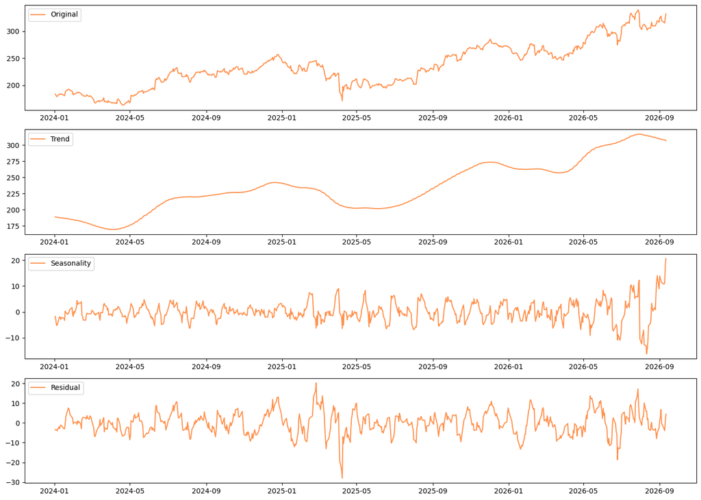

```python
from statsmodels.tsa.seasonal import STL
stl = STL(endog,period=30)
result = stl.fit()
plt.figure(figsize =(14,10))
plt.subplot(411)
plt.plot(result.observed,label="Original",color="#FF914D")
plt.legend(loc="upper left")
plt.subplot(412)
plt.plot(result.trend,label="Trend",color="#FF914D")
plt.legend(loc="upper left")
plt.subplot(413)
plt.plot(result.seasonal,label="Seasonality",color="#FF914D")
plt.legend(loc="upper left")
plt.subplot(414)
plt.plot(result.resid,label="Residual",color="#FF914D")
plt.legend(loc='upper left')
plt.tight_layout()
plt.show()
```

Stationarity

When,  
(weak stationarity) mean(no trend)  
variance  
acf all remain constant

Makes prediction easier it assumes same statistical properties throughout time

Forecasting models require a stationary data

Strong stationarity means : Joint distribution will remain the same even when shifted across time

For different forecasting models and shorter periods of data--> weak stationarity  
For long time of forecasting, we need stationarity strong to model entire data distribution

Test for stationarity

Weak stationarity  
ADF test  
and Kpss test

ADF test:presence of unit root which is a non stationary trend.  
H0 Null hypothesis --> data has a unit root(non stationary)  
H1 Alt Hypothesis -->stationary.  
If significance value is 0.05, and p<0.05 we reject null hypothesis

Kpss Test Fits a constant mean model on the data and measures variance of the cumulative sum of residual,  
H0 Null hypothesis --> stationary  
H1 Alt Hypothesis -->non stationary  
if p < significance value, we reject null hypothesis and data is non stationary

Strict stationarity Test: KS Test checks empirical/cumulative distribution functions of two samples.  
if p>significance value there is no difference in distribution(stationary)

```python
from statsmodels.tsa.stattools import adfuller
adf_test = adfuller(stock_data["Close"])
print("Adf Test Results")
print(f"Adf statistic: {round(adf_test[0],3)}")
print(f"p-value: {round(adf_test[1],3)}")
print('Critical Values:')
for key, value in adf_test[4].items():
    print(f'{key}: {round(value,3)}')
```

```
Adf Test Results
Adf statistic: -0.367
p-value: 0.916
Critical Values:
1%: -3.44
5%: -2.866
10%: -2.569
```

```python
pip install --upgrade statsmodels
```

[output not shown]

[output cut: 113 more lines]

[output not shown]

[output not shown]

```python
from statsmodels.tsa.stattools import kpss
kpss_test = kpss(stock_data["Close"],regression = "ct")
print("Kpss Test Results")
print(f"Kpss statistic: {round(kpss_test[0],3)}")
print(f'p-value:{kpss_test[1]}')
print('Critical Values:')
for key, value in kpss_test[3].items():
    print(f'{key}: {value}')
```

```
Kpss Test Results
Kpss statistic: 0.349
p-value:0.01
Critical Values:
10%: 0.119
5%: 0.146
2.5%: 0.176
1%: 0.216
```

Data is therefore non stationary

```
Strict Stationary ks stat 0.068 and pvalue 0.6109101078019121
Non Strict Stationary ks stat 0.184 and pvalue 0.00040888636357191906
```

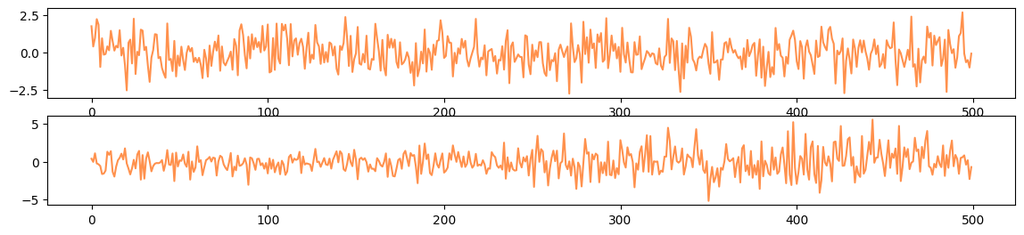

```python
import numpy as np
import matplotlib.pyplot as plt
from scipy.stats import kstest,ks_2samp
np.random.seed(0)
n = 500
#normal distribution random noise ---> strict stationary data
strict_stationary_series = np.random.normal(0,1,n)
#non strictly stationary--> introduce variance
non_strict_stationary_series = np.concatenate([np.random.normal(0,1,n//2),
np.random.normal(0,2,n//2)])
def ks_test_stationary(series):
    split = len(series)//2
    series_first_half = series[:split]
    series_second_half = series[split:]
    stat, p_value = ks_2samp(series_first_half, series_second_half)
    return stat,p_value
ks_stat_strict,ks_pvalue_strict = ks_test_stationary(strict_stationary_series)
ks_stat_nonstrict,ks_pvalue_nonstrict = ks_test_stationary(non_strict_stationary_series)
plt.figure(figsize=(14,6))
plt.subplot(411)

plt.plot(strict_stationary_series,label="Strict Stationary ks stat {ks_stat_strict} and pvalue {ks_pvalue_strict}",color="#FF914D")

plt.subplot(412)
plt.plot(non_strict_stationary_series,label="Non Strict Stationary ks stat {ks_stat_nonstrict} and pvalue {ks_pvalue_nonstrict}",color="#FF914D")
print(f"Strict Stationary ks stat {ks_stat_strict} and pvalue {ks_pvalue_strict}")
print(f"Non Strict Stationary ks stat {ks_stat_nonstrict} and pvalue {ks_pvalue_nonstrict}")
```

We see pvalue for stationary > 0.05 so it is stationary, no difference in distribution

Making a non Time series data into stationary data

1>Differencing

```python
stock_data["Close"].diff()
```

| Ticker Date | AAPL |
| --- | --- |
| 2024-01-02 | NaN |
| 2024-01-03 | -1.373260 |
| 2024-01-04 | -2.311829 |
| 2024-01-05 | -0.721176 |
| 2024-01-08 | 4.327240 |
| ... | ... |
| 2026-09-04 | -8.239990 |
| 2026-09-08 | -3.750000 |
| 2026-09-09 | -0.880005 |
| 2026-09-10 | 11.230011 |
| 2026-09-11 | 5.699982 |

676 rows × 1 columns

2> Transforming

```python
import numpy as np
np.log(stock_data["Close"])
```

| Ticker Date | AAPL |
| --- | --- |
| 2024-01-02 | 5.211691 |
| 2024-01-03 | 5.204176 |
| 2024-01-04 | 5.191394 |
| 2024-01-05 | 5.187373 |
| 2024-01-08 | 5.211260 |
| ... | ... |
| 2026-09-04 | 5.768227 |
| 2026-09-08 | 5.756438 |
| 2026-09-09 | 5.753651 |
| 2026-09-10 | 5.788644 |
| 2026-09-11 | 5.805948 |

676 rows × 1 columns

```python
np.sqrt(stock_data["Close"])
```

| Ticker Date | AAPL |
| --- | --- |
| 2024-01-02 | 13.542674 |
| 2024-01-03 | 13.491877 |
| 2024-01-04 | 13.405928 |
| 2024-01-05 | 13.379004 |
| 2024-01-08 | 13.539756 |
| ... | ... |
| 2026-09-04 | 17.887705 |
| 2026-09-08 | 17.782576 |
| 2026-09-09 | 17.757815 |
| 2026-09-10 | 18.071248 |
| 2026-09-11 | 18.228274 |

676 rows × 1 columns

```python
#box_cox
from scipy import stats
prices = stock_data['Close']
prices_boxcox , lam = stats.boxcox(prices[prices>0].squeeze())
```

```python
from scipy import signal
trend = np.polyfit(np.arange(len(prices)),prices,1)
trendline = np.polyval(trend,np.arange(len(prices)))

prices_detrend = stock_data['Close'].squeeze() - trendline
#detrending
```

```python
#moving average
window = 12
prices_ma = prices.rolling(window=window).mean()
prices_detrended = prices - prices_ma
prices_detrended = prices_detrended.dropna()
```

```python
import numpy as np
#seasonal decomposition stl decomposition
from statsmodels.tsa.seasonal import seasonal_decompose
decomposition = seasonal_decompose(stock_data['Close'],model='additive',period=30)
prices_adjusted = stock_data["Close"].squeeze()/decomposition.seasonal
prices_adjusted = prices_adjusted[~np.isnan(prices_adjusted)]
```

```python
def weak_stationary_test(series):
    kpss_test = kpss(series,regression = "ct")
    print("Kpss Test Results")
    print(f"Kpss statistic: {round(kpss_test[0],3)}")
    print(f'p-value:{kpss_test[1]}')
    print('Critical Values:')
    for key, value in kpss_test[3].items():
        print(f'{key}: {value}')
    adf_test = adfuller(series)
    print("Adf Test Results")
    print(f"Adf statistic: {round(adf_test[0],3)}")
    print(f"p-value: {round(adf_test[1],3)}")
    print('Critical Values:')
    for key, value in adf_test[4].items():
        print(f'{key}: {round(value,3)}')

    if(kpss_test[1]<0.05 and round(adf_test[1],3)>0.05):
        return "Non stationary"
    elif(kpss_test[1]>0.05 and round(adf_test[1],3)<0.05):
        return "Stationary"
    else:
        return "can't conclude"
```

```python
weak_stationary_test(stock_data["Close"].diff().dropna())
```

```
Kpss Test Results
Kpss statistic: 0.042
p-value:0.1
Critical Values:
10%: 0.119
5%: 0.146
2.5%: 0.176
1%: 0.216
Adf Test Results
Adf statistic: -13.198
p-value: 0.0
Critical Values:
1%: -3.44
5%: -2.866
10%: -2.569
```

```
'Stationary'
```

```python
weak_stationary_test(stock_data["Close"].diff().diff().dropna())
```

```
Kpss Test Results
Kpss statistic: 0.085
p-value:0.1
Critical Values:
10%: 0.119
5%: 0.146
2.5%: 0.176
1%: 0.216
Adf Test Results
Adf statistic: -10.574
p-value: 0.0
Critical Values:
1%: -3.44
5%: -2.866
10%: -2.569
```

```
'Stationary'
```

```python
weak_stationary_test(np.log(stock_data["Close"]))
```

```
Kpss Test Results
Kpss statistic: 0.275
p-value:0.01
Critical Values:
10%: 0.119
5%: 0.146
2.5%: 0.176
1%: 0.216
Adf Test Results
Adf statistic: -0.672
p-value: 0.854
Critical Values:
1%: -3.44
5%: -2.866
10%: -2.569
```

```
'Non stationary'
```

```python
weak_stationary_test(np.sqrt(stock_data["Close"]))
```

```
Kpss Test Results
Kpss statistic: 0.307
p-value:0.01
Critical Values:
10%: 0.119
5%: 0.146
2.5%: 0.176
1%: 0.216
Adf Test Results
Adf statistic: -0.51
p-value: 0.89
Critical Values:
1%: -3.44
5%: -2.866
10%: -2.569
```

```
'Non stationary'
```

```python
weak_stationary_test(prices_boxcox)
```

```
Kpss Test Results
Kpss statistic: 0.269
p-value:0.01
Critical Values:
10%: 0.119
5%: 0.146
2.5%: 0.176
1%: 0.216
Adf Test Results
Adf statistic: -0.705
p-value: 0.845
Critical Values:
1%: -3.44
5%: -2.866
10%: -2.569
```

```
'Non stationary'
```

```python
weak_stationary_test(prices_detrend)
```

```
Kpss Test Results
Kpss statistic: 0.346
p-value:0.01
Critical Values:
10%: 0.119
5%: 0.146
2.5%: 0.176
1%: 0.216
Adf Test Results
Adf statistic: -2.062
p-value: 0.26
Critical Values:
1%: -3.44
5%: -2.866
10%: -2.569
```

```
'Non stationary'
```

```python
weak_stationary_test(prices_detrended)
```

```
Kpss Test Results
Kpss statistic: 0.055
p-value:0.1
Critical Values:
10%: 0.119
5%: 0.146
2.5%: 0.176
1%: 0.216
Adf Test Results
Adf statistic: -8.48
p-value: 0.0
Critical Values:
1%: -3.44
5%: -2.866
10%: -2.569
```

```
'Stationary'
```

```python
weak_stationary_test(prices_adjusted)
```

```
Kpss Test Results
Kpss statistic: 0.009
p-value:0.1
Critical Values:
10%: 0.119
5%: 0.146
2.5%: 0.176
1%: 0.216
Adf Test Results
Adf statistic: -8.929
p-value: 0.0
Critical Values:
1%: -3.44
5%: -2.866
10%: -2.569
```

```
'Stationary'
```

White Noise and Random Walk

White noise: if a time series data has no pattern, trend or seasonality. Same mean, constant variance and no acf , then it has white noise. very random-->unpredictable

Random Walk(non stationary) : cumulative pattern yt = yt-1 +e , it is predictable. Mean and variance change overtime. First diff is stationary then it becomes predictable

Check how: Visual analysis ACF and PACF Ljung Box

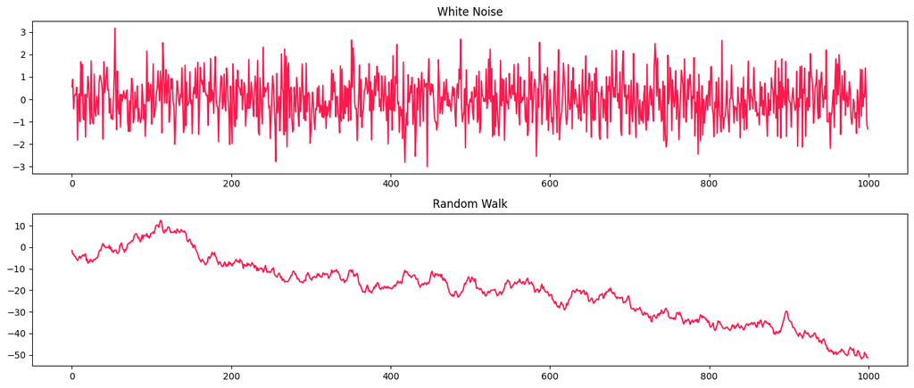

```
Ljung Box Test for white noise
     lb_stat  lb_pvalue
10  8.297906   0.599763
```

```python
from statsmodels.stats.diagnostic import acorr_ljungbox
np.random.seed(0)
n = 1000
#Generate white noise
np.random.normal(0,1,n)
white_noise = np.random.normal(0,1,n)
#randomwalk generate
random_shocks = np.random.normal(0,1,n)
random_walk = np.cumsum(random_shocks)

plt.figure(figsize=(14,6))
plt.subplot(2,1,1)
plt.plot(white_noise,color = "#FF194D")
plt.title(f"White Noise")


plt.subplot(2,1,2)
plt.plot(random_walk,color="#FF194D")
plt.title(f"Random Walk")

plt.tight_layout()
plt.show()

#Ljung-Box test

print('\nLjung Box Test for white noise')
lb_test_white_noise = acorr_ljungbox(white_noise, lags = [10], return_df = True)
print(lb_test_white_noise)
```

```python
print('\nLjung Box Test for random_walk')
lb_test_rw_noise = acorr_ljungbox(random_walk, lags = [10], return_df = True)
print(lb_test_rw_noise)
```

```
Ljung Box Test for random_walk
        lb_stat  lb_pvalue
10  9510.565455        0.0
```

Since Lb_pvalue>0.05 for white noise,  
pvalue < 0.05 then it is random_walk  
H0:white noise  
H1:not white noise  
H0:random walk  
H1:not random walk  
if p<0.05 we know it is reject null hypothesis, it is random walk

# Forecasting Models

Autoregressive(AR)(p)  
Moving Average (MA)(q)  
Autoregressive Moving Average(ARMA)(p,q)  
Autoregressive Integrated Moving Average(ARIMA)(p,d,q)  
Seasonal Autoregressive Integrated Moving Average(SARIMA)(pdq)(PDQ)m  
Vector Autoregressive(VAR)  
Vector Moving Average (VMA)  
VARIMA  
VARMA

# AR MODEL

```python
#Since we have verified the data is non stationary, we have to make it stationary. We can first difference method
```

```python
apple_price_stationary = stock_data["Close"].diff().dropna()
```

```python
train_data, test_data = apple_price_stationary[:-30], apple_price_stationary[-30:]
```

```python
train_data = train_data.reset_index(drop=True)
test_data = test_data.reset_index(drop=True)
```

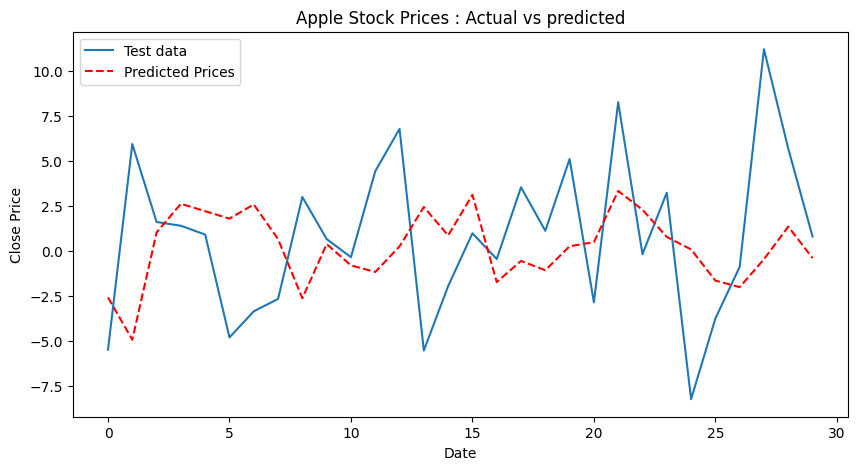

```
RMSE:4.93
```

```python
from statsmodels.tsa.ar_model import AutoReg
from sklearn.metrics import mean_squared_error
import numpy as np
import warnings
warnings.filterwarnings('ignore')
#Fit the auto regressive model to the training data
model = AutoReg(train_data, lags = 30)
model_fit = model.fit()
# Using integer indices based on array length
start_idx = len(train_data)
end_idx = len(train_data) + len(test_data) - 1
prediction = model_fit.predict(start=start_idx, end=end_idx, dynamic=False)
#Plot the actual vs predicted values

#plot the actual vs predicted values
plt.figure(figsize =(10,5))
plt.plot(test_data.index, test_data, label="Test data")
plt.plot(test_data.index,prediction,color='red',linestyle="--",label ="Predicted Prices")
plt.title("Apple Stock Prices : Actual vs predicted")
plt.xlabel("Date")
plt.ylabel('Close Price')
plt.legend()
plt.show()

rmse = round(np.sqrt(mean_squared_error(test_data, prediction)),2)

print(f"RMSE:{rmse}")
```

# MA Model

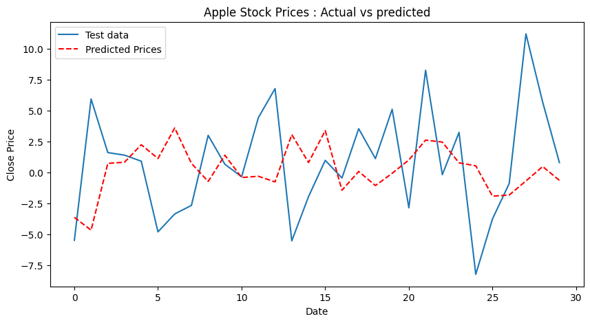

```
RMSE:5.01
```

```python
from statsmodels.tsa.arima.model import ARIMA
from sklearn.metrics import mean_squared_error
import numpy as np
import warnings
warnings.filterwarnings('ignore')
#Fit the auto regressive model to the training data
model = ARIMA(train_data, order = (0,0,30))#(p,d,q) = (0,0,30)
model_fit = model.fit()
# Using integer indices based on array length
start_idx = len(train_data)
end_idx = len(train_data) + len(test_data) - 1
prediction = model_fit.predict(start=start_idx, end=end_idx, dynamic=False)
#Plot the actual vs predicted values

plt.figure(figsize =(10,5))
plt.plot(test_data.index, test_data, label="Test data")
plt.plot(test_data.index,prediction,color='red',linestyle="--",label ="Predicted Prices")
plt.title("Apple Stock Prices : Actual vs predicted")
plt.xlabel("Date")
plt.ylabel('Close Price')
plt.legend()
plt.show()

rmse = round(np.sqrt(mean_squared_error(test_data, prediction)),2)

print(f"RMSE:{rmse}")
```

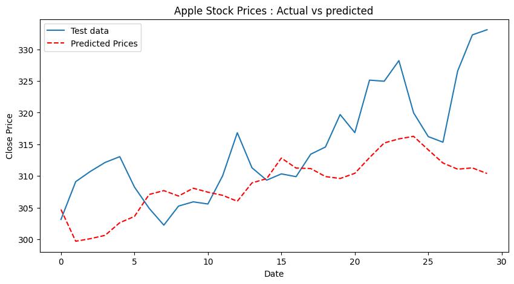

```
RMSE:9.02
```

```python
apple_price_stationary = stock_data["Close"]
train_data, test_data = apple_price_stationary[:-30], apple_price_stationary[-30:]
train_data = train_data.reset_index(drop=True)
test_data = test_data.reset_index(drop=True)

model = ARIMA(train_data, order = (0,1,30))#(p,d,q) = (0,1,30)
model_fit = model.fit()
# Using integer indices based on array length
start_idx = len(train_data)
end_idx = len(train_data) + len(test_data) - 1
prediction = model_fit.predict(start=start_idx, end=end_idx, dynamic=False)


#plot the actual vs predicted values
plt.figure(figsize =(10,5))
plt.plot(test_data.index, test_data, label="Test data")
plt.plot(test_data.index,prediction,color='red',linestyle="--",label ="Predicted Prices")
plt.title("Apple Stock Prices : Actual vs predicted")
plt.xlabel("Date")
plt.ylabel('Close Price')
plt.legend()
plt.show()

rmse = round(np.sqrt(mean_squared_error(test_data, prediction)),2)

print(f"RMSE:{rmse}")
```

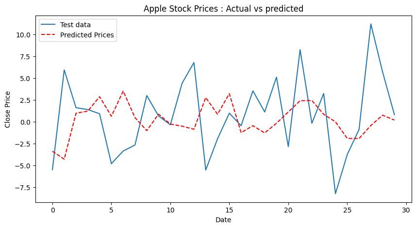

```
RMSE:4.92
```

```python
apple_price_stationary = stock_data["Close"].diff().dropna()
train_data, test_data = apple_price_stationary[:-30], apple_price_stationary[-30:]
train_data = train_data.reset_index(drop=True)
test_data = test_data.reset_index(drop=True)

model = ARIMA(train_data, order = (0,1,30))#(p,d,q) = (0,1,30)
model_fit = model.fit()
# Using integer indices based on array length
start_idx = len(train_data)
end_idx = len(train_data) + len(test_data) - 1
prediction = model_fit.predict(start=start_idx, end=end_idx, dynamic=False)


#plot the actual vs predicted values
plt.figure(figsize =(10,5))
plt.plot(test_data.index, test_data, label="Test data")
plt.plot(test_data.index,prediction,color='red',linestyle="--",label ="Predicted Prices")
plt.title("Apple Stock Prices : Actual vs predicted")
plt.xlabel("Date")
plt.ylabel('Close Price')
plt.legend()
plt.show()

rmse = round(np.sqrt(mean_squared_error(test_data, prediction)),2)

print(f"RMSE:{rmse}")
```

# ARIMA model

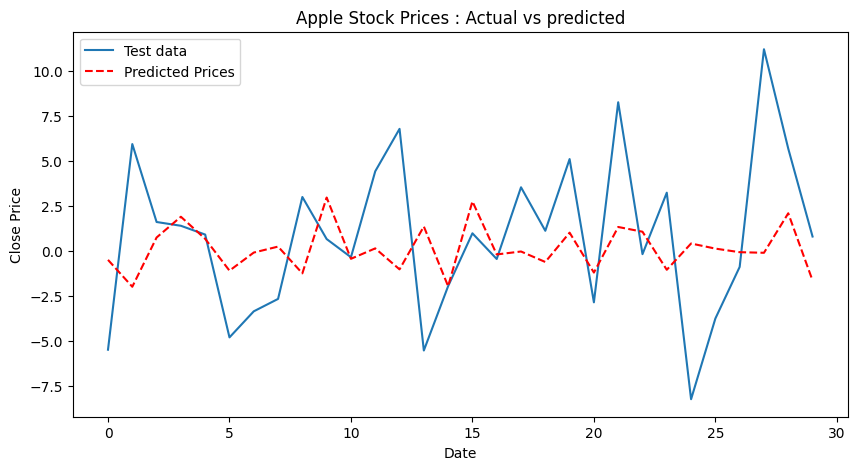

```
RMSE:4.54
```

```python
model = ARIMA(train_data, order = (7,1,7))#(p,d,q) = (7,1,7)
model_fit = model.fit()
# Using integer indices based on array length
start_idx = len(train_data)
end_idx = len(train_data) + len(test_data) - 1
prediction = model_fit.predict(start=start_idx, end=end_idx, dynamic=False)


#plot the actual vs predicted values
plt.figure(figsize =(10,5))
plt.plot(test_data.index, test_data, label="Test data")
plt.plot(test_data.index,prediction,color='red',linestyle="--",label ="Predicted Prices")
plt.title("Apple Stock Prices : Actual vs predicted")
plt.xlabel("Date")
plt.ylabel('Close Price')
plt.legend()
plt.show()

rmse = round(np.sqrt(mean_squared_error(test_data, prediction)),2)

print(f"RMSE:{rmse}")
```

# SARIMA Model

```
Fit time: 250.0s
```

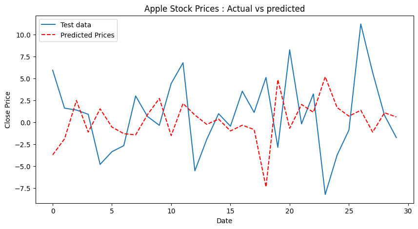

[output not shown]

```python
import time
t0 = time.time()
from statsmodels.tsa.statespace.sarimax import SARIMAX
p,d,q = 7,1,7
P,D,Q,m= 1,1,1,45
model = SARIMAX(train_data, order = (p,d,q), seasonal_order = (P,D,Q,m))
model_fit = model.fit(disp=False, maxiter=10)
print(f"Fit time: {time.time() - t0:.1f}s")
start_idx = len(train_data)
end_idx = len(train_data) + len(test_data) - 1
prediction = model_fit.predict(start=start_idx, end=end_idx, dynamic=False)


#plot the actual vs predicted values
plt.figure(figsize =(10,5))
plt.plot(test_data.index, test_data, label="Test data")
plt.plot(test_data.index,prediction,color='red',linestyle="--",label ="Predicted Prices")
plt.title("Apple Stock Prices : Actual vs predicted")
plt.xlabel("Date")
plt.ylabel('Close Price')
plt.legend()
plt.show()
import numpy as np
```

```python
from sklearn.metrics import mean_squared_error
rmse = round(np.sqrt(mean_squared_error(test_data, prediction)),2)

print(f"RMSE:{rmse}")
```

```
RMSE:5.71
```

# Vector Models

```python
tsla_data = yf.download('TSLA',start = '2023-01-01')
stock_data['TSLA_Close'] = tsla_data['Close']
stock_data['AAPL_Close'] = stock_data['Close'].shift()
stock_data.dropna(inplace = True)

from statsmodels.tsa.stattools import grangercausalitytests
```

```
[*********************100%***********************]  1 of 1 completed
```

```python
grangercausalitytests(stock_data[['AAPL_Close','TSLA_Close']].dropna(),maxlag=[14])
```

```
{14: ({'ssr_ftest': (6.093950246031769, 2.0235441906252198e-11, 633.0, 14),
   'ssr_chi2test': (89.22390344426924, 5.317784684209074e-13, 14),
   'lrtest': (83.7020829697858, 5.788016118841763e-12, 14),
   'params_ftest': (6.093950246031862, 2.023544190624235e-11, 633.0, 14.0)},
  [<statsmodels.regression.linear_model.RegressionResultsWrapper at 0x291ddafc290>,
   <statsmodels.regression.linear_model.RegressionResultsWrapper at 0x291e08cb150>,
   array([[0., 0., 0., 0., 0., 0., 0., 0., 0., 0., 0., 0., 0., 0., 1., 0.,
           0., 0., 0., 0., 0., 0., 0., 0., 0., 0., 0., 0., 0.],
          [0., 0., 0., 0., 0., 0., 0., 0., 0., 0., 0., 0., 0., 0., 0., 1.,
           0., 0., 0., 0., 0., 0., 0., 0., 0., 0., 0., 0., 0.],
          [0., 0., 0., 0., 0., 0., 0., 0., 0., 0., 0., 0., 0., 0., 0., 0.,
           1., 0., 0., 0., 0., 0., 0., 0., 0., 0., 0., 0., 0.],
          [0., 0., 0., 0., 0., 0., 0., 0., 0., 0., 0., 0., 0., 0., 0., 0.,
           0., 1., 0., 0., 0., 0., 0., 0., 0., 0., 0., 0., 0.],
          [0., 0., 0., 0., 0., 0., 0., 0., 0., 0., 0., 0., 0., 0., 0., 0.,
           0., 0., 1., 0., 0., 0., 0., 0., 0., 0., 0., 0., 0.],
          [0., 0., 0., 0., 0., 0., 0., 0., 0., 0., 0., 0., 0., 0., 0., 0.,
           0., 0., 0., 1., 0., 0., 0., 0., 0., 0., 0., 0., 0.],
          [0., 0., 0., 0., 0., 0., 0., 0., 0., 0., 0., 0., 0., 0., 0., 0.,
           0., 0., 0., 0., 1., 0., 0., 0., 0., 0., 0., 0., 0.],
          [0., 0., 0., 0., 0., 0., 0., 0., 0., 0., 0., 0., 0., 0., 0., 0.,
           0., 0., 0., 0., 0., 1., 0., 0., 0., 0., 0., 0., 0.],
          [0., 0., 0., 0., 0., 0., 0., 0., 0., 0., 0., 0., 0., 0., 0., 0.,
           0., 0., 0., 0., 0., 0., 1., 0., 0., 0., 0., 0., 0.],
          [0., 0., 0., 0., 0., 0., 0., 0., 0., 0., 0., 0., 0., 0., 0., 0.,
           0., 0., 0., 0., 0., 0., 0., 1., 0., 0., 0., 0., 0.],
          [0., 0., 0., 0., 0., 0., 0., 0., 0., 0., 0., 0., 0., 0., 0., 0.,
           0., 0., 0., 0., 0., 0., 0., 0., 1., 0., 0., 0., 0.],
          [0., 0., 0., 0., 0., 0., 0., 0., 0., 0., 0., 0., 0., 0., 0., 0.,
           0., 0., 0., 0., 0., 0., 0., 0., 0., 1., 0., 0., 0.],
          [0., 0., 0., 0., 0., 0., 0., 0., 0., 0., 0., 0., 0., 0., 0., 0.,
           0., 0., 0., 0., 0., 0., 0., 0., 0., 0., 1., 0., 0.],
          [0., 0., 0., 0., 0., 0., 0., 0., 0., 0., 0., 0., 0., 0., 0., 0.,
           0., 0., 0., 0., 0., 0., 0., 0., 0., 0., 0., 1., 0.]])])}
```

```python
grangercausalitytests(stock_data[['TSLA_Close','AAPL_Close']].dropna(),maxlag=[14])
```

```
{14: ({'ssr_ftest': (1.1272711713539463, 0.32979771507939376, 633.0, 14),
   'ssr_chi2test': (16.504817087059042, 0.2835268828297453, 14),
   'lrtest': (16.3024271764707, 0.2952564090200724, 14),
   'params_ftest': (1.1272711713540011, 0.32979771507935796, 633.0, 14.0)},
  [<statsmodels.regression.linear_model.RegressionResultsWrapper at 0x291ddad9a90>,
   <statsmodels.regression.linear_model.RegressionResultsWrapper at 0x291e0819ed0>,
   array([[0., 0., 0., 0., 0., 0., 0., 0., 0., 0., 0., 0., 0., 0., 1., 0.,
           0., 0., 0., 0., 0., 0., 0., 0., 0., 0., 0., 0., 0.],
          [0., 0., 0., 0., 0., 0., 0., 0., 0., 0., 0., 0., 0., 0., 0., 1.,
           0., 0., 0., 0., 0., 0., 0., 0., 0., 0., 0., 0., 0.],
          [0., 0., 0., 0., 0., 0., 0., 0., 0., 0., 0., 0., 0., 0., 0., 0.,
           1., 0., 0., 0., 0., 0., 0., 0., 0., 0., 0., 0., 0.],
          [0., 0., 0., 0., 0., 0., 0., 0., 0., 0., 0., 0., 0., 0., 0., 0.,
           0., 1., 0., 0., 0., 0., 0., 0., 0., 0., 0., 0., 0.],
          [0., 0., 0., 0., 0., 0., 0., 0., 0., 0., 0., 0., 0., 0., 0., 0.,
           0., 0., 1., 0., 0., 0., 0., 0., 0., 0., 0., 0., 0.],
          [0., 0., 0., 0., 0., 0., 0., 0., 0., 0., 0., 0., 0., 0., 0., 0.,
           0., 0., 0., 1., 0., 0., 0., 0., 0., 0., 0., 0., 0.],
          [0., 0., 0., 0., 0., 0., 0., 0., 0., 0., 0., 0., 0., 0., 0., 0.,
           0., 0., 0., 0., 1., 0., 0., 0., 0., 0., 0., 0., 0.],
          [0., 0., 0., 0., 0., 0., 0., 0., 0., 0., 0., 0., 0., 0., 0., 0.,
           0., 0., 0., 0., 0., 1., 0., 0., 0., 0., 0., 0., 0.],
          [0., 0., 0., 0., 0., 0., 0., 0., 0., 0., 0., 0., 0., 0., 0., 0.,
           0., 0., 0., 0., 0., 0., 1., 0., 0., 0., 0., 0., 0.],
          [0., 0., 0., 0., 0., 0., 0., 0., 0., 0., 0., 0., 0., 0., 0., 0.,
           0., 0., 0., 0., 0., 0., 0., 1., 0., 0., 0., 0., 0.],
          [0., 0., 0., 0., 0., 0., 0., 0., 0., 0., 0., 0., 0., 0., 0., 0.,
           0., 0., 0., 0., 0., 0., 0., 0., 1., 0., 0., 0., 0.],
          [0., 0., 0., 0., 0., 0., 0., 0., 0., 0., 0., 0., 0., 0., 0., 0.,
           0., 0., 0., 0., 0., 0., 0., 0., 0., 1., 0., 0., 0.],
          [0., 0., 0., 0., 0., 0., 0., 0., 0., 0., 0., 0., 0., 0., 0., 0.,
           0., 0., 0., 0., 0., 0., 0., 0., 0., 0., 1., 0., 0.],
          [0., 0., 0., 0., 0., 0., 0., 0., 0., 0., 0., 0., 0., 0., 0., 0.,
           0., 0., 0., 0., 0., 0., 0., 0., 0., 0., 0., 1., 0.]])])}
```

We performed bilateral testing. We have tested if apple stocks get affected by tesla, or if it is vice versa, or both.

h0 : x does not granger cause y  
h1 : x granger causes y  
Here we see in case 1, where AAPL is dependent y and Tesla is independent x, p value comes out to be ~ 0 < 0.05 so we reject the null hypothesis, apple stock prices at close are dependent on tesla stock prices at close.  
In case 2 we see, the p value > 0.05 , so null hypothesis can't be rejected, so we can say apple stock closing prices donot granger cause tesla stock closing prices.

```python
data = stock_data[['AAPL_Close','TSLA_Close']].diff().dropna()
```

```python
train_data, test_data = data[:-14],data[-14:]
train_data = train_data.reset_index(drop=True)
test_data = test_data.reset_index(drop=True)
```

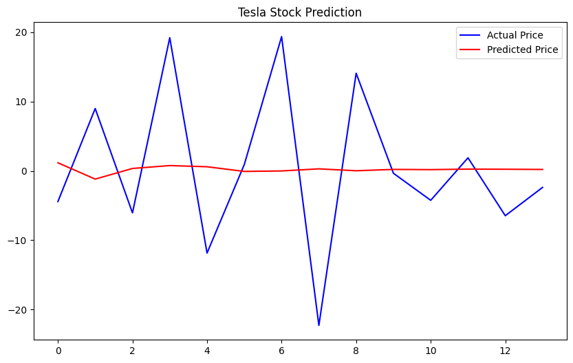

```
RMSE:  11.43
```

```python
from statsmodels.tsa.api import VAR, VARMAX
import pandas as pd
#VAR
model = VAR(train_data)
result = model.fit(maxlags = 7)
predictions = result.forecast(train_data.values[-result.k_ar:],steps = len(test_data))

predictions = pd.DataFrame(predictions, index = test_data.index, columns = test_data.columns)
plt.figure(figsize =(10,6))
plt.plot(test_data.index, test_data['TSLA_Close'],label = "Actual Price",color = "blue")
plt.plot(test_data.index, predictions['TSLA_Close'],label = "Predicted Price",color = "red")
plt.legend()
plt.title('Tesla Stock Prediction')
plt.show()

print(f"RMSE: ", round(np.sqrt(mean_squared_error(test_data["TSLA_Close"], predictions["TSLA_Close"])),2))
```

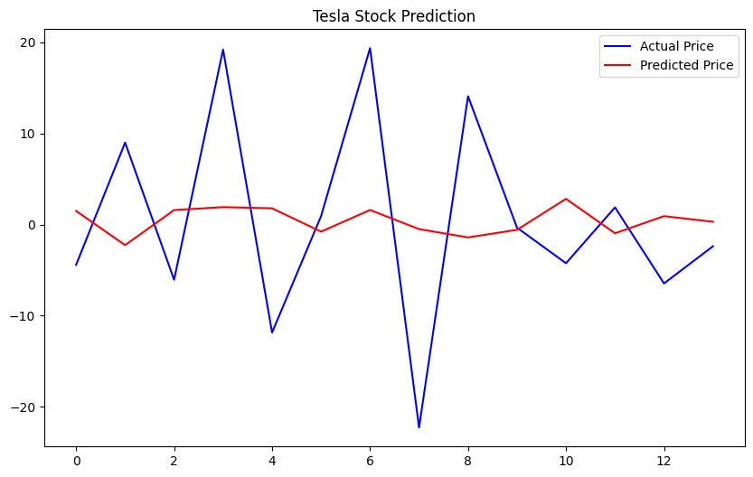

```
RMSE:  11.52
```

```python
#Changing MAx LAGs
data = stock_data[['AAPL_Close','TSLA_Close']].diff().dropna()
train_data, test_data = data[:-14],data[-14:]
train_data = train_data.reset_index(drop=True)
test_data = test_data.reset_index(drop=True)
#VAR
model = VAR(train_data)
result = model.fit(maxlags = 14)
predictions = result.forecast(train_data.values[-result.k_ar:],steps = len(test_data))

predictions = pd.DataFrame(predictions, index = test_data.index, columns = test_data.columns)
plt.figure(figsize =(10,6))
plt.plot(test_data.index, test_data['TSLA_Close'],label = "Actual Price",color = "blue")
plt.plot(test_data.index, predictions['TSLA_Close'],label = "Predicted Price",color = "red")
plt.legend()
plt.title('Tesla Stock Prediction')
plt.show()

print(f"RMSE: ", round(np.sqrt(mean_squared_error(test_data["TSLA_Close"], predictions["TSLA_Close"])),2))
```

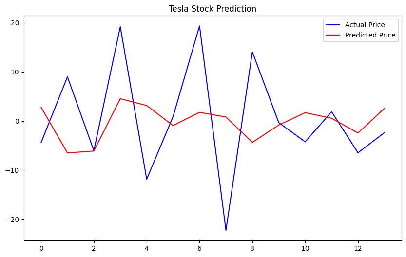

```
RMSE:  11.95
```

```python
data = stock_data[['AAPL_Close','TSLA_Close']].diff().dropna()
train_data, test_data = data[:-14],data[-14:]
train_data = train_data.reset_index(drop=True)
test_data = test_data.reset_index(drop=True)
#VAR
model = VAR(train_data)
result = model.fit(maxlags = 20)
predictions = result.forecast(train_data.values[-result.k_ar:],steps = len(test_data))

predictions = pd.DataFrame(predictions, index = test_data.index, columns = test_data.columns)
plt.figure(figsize =(10,6))
plt.plot(test_data.index, test_data['TSLA_Close'],label = "Actual Price",color = "blue")
plt.plot(test_data.index, predictions['TSLA_Close'],label = "Predicted Price",color = "red")
plt.legend()
plt.title('Tesla Stock Prediction')
plt.show()

print(f"RMSE: ", round(np.sqrt(mean_squared_error(test_data["TSLA_Close"], predictions["TSLA_Close"])),2))
```

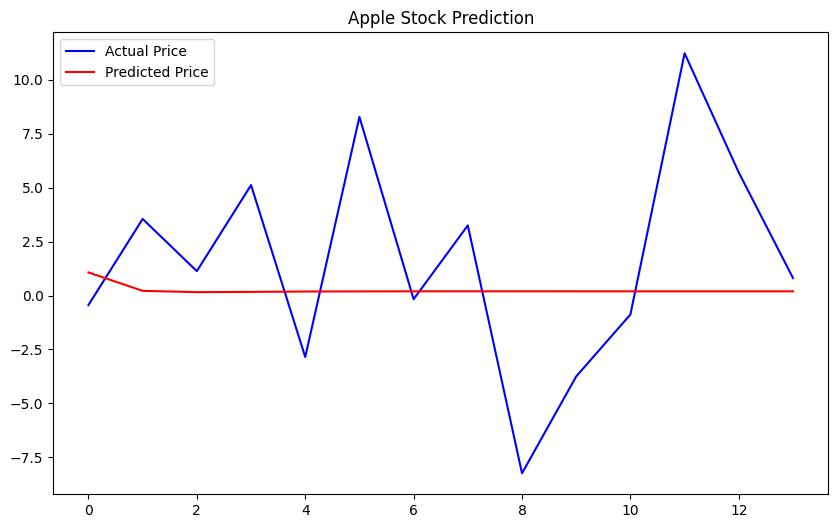

```
RMSE:  5.09
```

```python
data = stock_data[['AAPL_Close','TSLA_Close']].diff().dropna()
train_data, test_data = data[:-14],data[-14:]
train_data = train_data.reset_index(drop=True)
test_data = test_data.reset_index(drop=True)
#VAR
model = VAR(train_data)
result = model.fit(maxlags = 3)
predictions = result.forecast(train_data.values[-result.k_ar:],steps = len(test_data))

predictions = pd.DataFrame(predictions, index = test_data.index, columns = test_data.columns)
plt.figure(figsize =(10,6))
plt.plot(test_data.index, test_data['AAPL_Close'],label = "Actual Price",color = "blue")
plt.plot(test_data.index, predictions['AAPL_Close'],label = "Predicted Price",color = "red")
plt.legend()
plt.title('Apple Stock Prediction')
plt.show()

print(f"RMSE: ", round(np.sqrt(mean_squared_error(test_data["AAPL_Close"], predictions["AAPL_Close"])),2))
```

```python
data = stock_data[['TSLA_Close','AAPL_Data']].diff().dropna()
train_data, test_data = data[:-14],data[-14:]
train_data = train_data.reset_index(drop=True)
test_data = test_data.reset_index(drop=True)
#VAR
model = VAR(train_data)
result = model.fit(maxlags = 5)
predictions = result.forecast(train_data.values[-result.k_ar:],steps = len(test_data))

predictions = pd.DataFrame(predictions, index = test_data.index, columns = test_data.columns)
plt.figure(figsize =(10,6))
plt.plot(test_data.index, test_data['TSLA_Close'],label = "Actual Price",color = "blue")
plt.plot(test_data.index, predictions['TSLA_Close'],label = "Predicted Price",color = "red")
plt.legend()
plt.title('Tesla Stock Prediction')
plt.show()

print(f"RMSE: ", round(np.sqrt(mean_squared_error(test_data["TSLA_Close"], predictions["TSLA_Close"])),2))
```

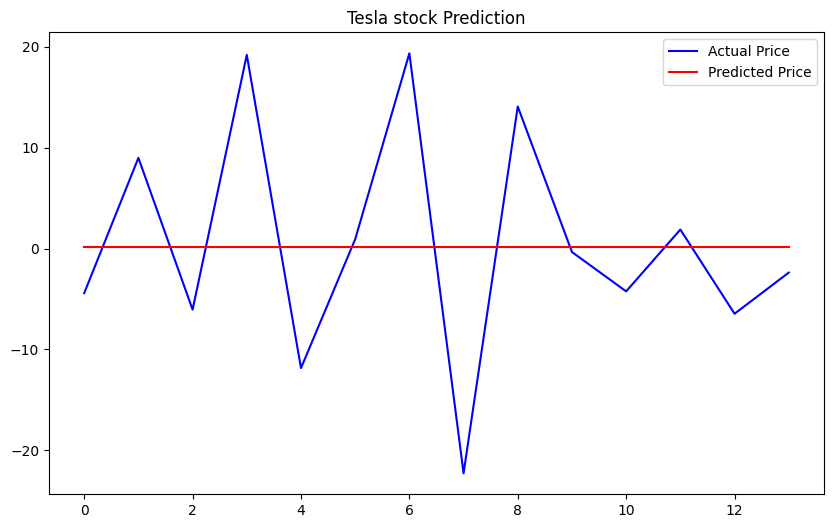

```
RMSE:  11.29
```

```python
#VMA
data = stock_data[['AAPL_Close','TSLA_Close']].diff().dropna()
train_data, test_data = data[:-14],data[-14:]
train_data = train_data.reset_index(drop=True)
test_data = test_data.reset_index(drop=True)

model = VARMAX(train_data, order = (0,14))
result = model.fit()
predictions = result.predict(start = len(train_data),end = len(train_data)+len(test_data)-1,dynamic = False)


plt.figure(figsize =(10,6))
plt.plot(test_data.index, test_data['TSLA_Close'],label = "Actual Price",color = "blue")
plt.plot(test_data.index, predictions['TSLA_Close'],label = "Predicted Price",color = "red")
plt.legend()
plt.title('Tesla stock Prediction')
plt.show()

print(f"RMSE: ", round(np.sqrt(mean_squared_error(test_data["TSLA_Close"], predictions["TSLA_Close"])),2))
```

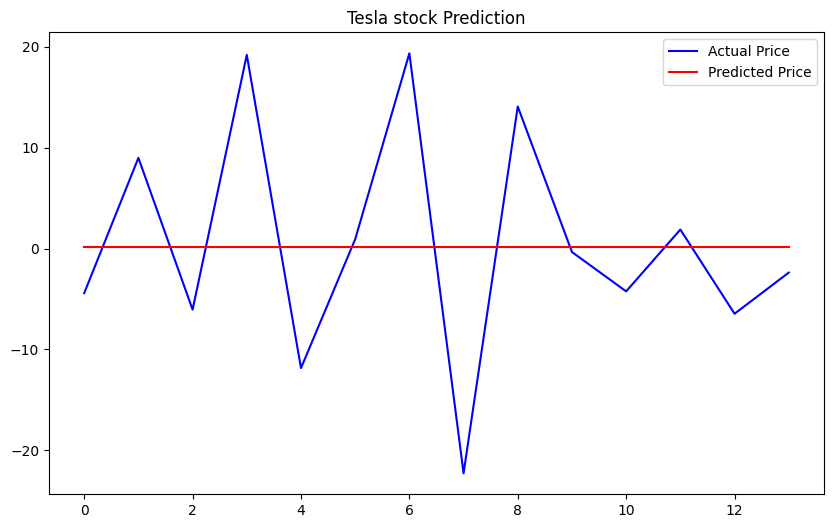

```
RMSE:  11.29
```

```python
data = stock_data[['AAPL_Close','TSLA_Close']].diff().dropna()
train_data, test_data = data[:-14],data[-14:]
train_data = train_data.reset_index(drop=True)
test_data = test_data.reset_index(drop=True)
#VARIMA
model = VARMAX(train_data, order = (14,14))
result = model.fit()
predictions = result.predict(start = len(train_data),end = len(train_data)+len(test_data)-1,dynamic = False)


plt.figure(figsize =(10,6))
plt.plot(test_data.index, test_data['TSLA_Close'],label = "Actual Price",color = "blue")
plt.plot(test_data.index, predictions['TSLA_Close'],label = "Predicted Price",color = "red")
plt.legend()
plt.title('Tesla stock Prediction')
plt.show()

print(f"RMSE: ", round(np.sqrt(mean_squared_error(test_data["TSLA_Close"], predictions["TSLA_Close"])),2))
```

# Smoothening Methods

Reduction of Noise, so that the forecast isn't noisy  
Good for forecasting high fluctuated time series data  
Trend Identification

Simple moving average  
weighted moving average  
exponential smoothing

Exponential smoothing: time series with no trend or seasonality  
Holt's model : for trend  
Winter Model: trend and seasonality

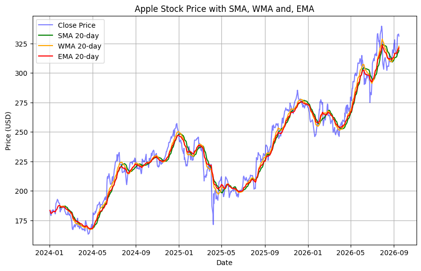

```python
window_size = 20
stock_data["SMA"] = stock_data["Close"].rolling(window = window_size).mean()

weights = np.arange(1,window_size+1)
stock_data["WMA"] = stock_data['Close'].rolling(window_size).apply(lambda prices:np.dot(prices,weights)/weights.sum(),raw=True)
stock_data['EMA'] = stock_data['Close'].ewm(span = window_size).mean()

plt.figure(figsize =(10,6))
plt.plot(stock_data['Close'],label = 'Close Price',color ='blue',alpha = 0.5)
plt.plot(stock_data['SMA'],label = f'SMA {window_size}-day',color ='green')
plt.plot(stock_data['WMA'],label = f'WMA {window_size}-day',color ='orange')
plt.plot(stock_data['EMA'],label = f'EMA {window_size}-day',color ='red')

plt.title('Apple Stock Price with SMA, WMA and, EMA')
plt.xlabel('Date')
plt.ylabel('Price (USD)')
plt.legend()
plt.grid()
plt.show()
```

```python
#Simple exponential, Holt's and Winter's model
```

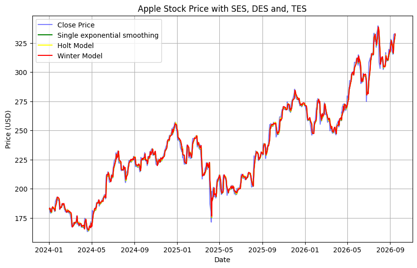

```python
from statsmodels.tsa.holtwinters import SimpleExpSmoothing, ExponentialSmoothing

close_prices = stock_data['Close']

ses_model = SimpleExpSmoothing(close_prices,initialization_method="estimated").fit(smoothing_level = 0.7)
stock_data['SES'] = ses_model.fittedvalues

des_model = ExponentialSmoothing(close_prices, trend = 'add'). fit(smoothing_level=0.7)
stock_data['DES'] = des_model.fittedvalues

tes_model = ExponentialSmoothing(close_prices, trend = 'add',seasonal = 'add', seasonal_periods = 12). fit(smoothing_level=0.7)
stock_data['TES'] = tes_model.fittedvalues



plt.figure(figsize =(10,6))
plt.plot(stock_data['Close'],label = 'Close Price',color ='blue',alpha = 0.5)
plt.plot(stock_data['SES'],label = 'Single exponential smoothing',color ='green')
plt.plot(stock_data['DES'],label = 'Holt Model',color ='yellow')
plt.plot(stock_data['TES'],label = 'Winter Model',color ='red')

plt.title('Apple Stock Price with SES, DES and, TES')
plt.xlabel('Date')
plt.ylabel('Price (USD)')
plt.legend()
plt.grid()
plt.show()
```

smoothening level can be reduced from 0.7 to 0.3, to smoothen it out more

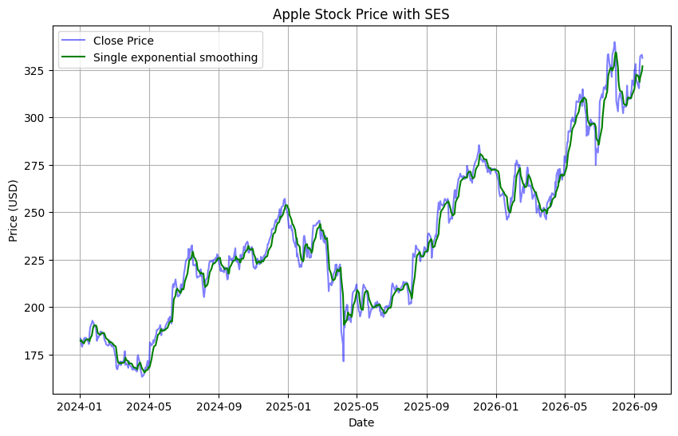

```python
ses_model = SimpleExpSmoothing(close_prices,initialization_method="estimated").fit(smoothing_level = 0.3)
stock_data['SES'] = ses_model.fittedvalues
plt.figure(figsize =(10,6))
plt.plot(stock_data['Close'],label = 'Close Price',color ='blue',alpha = 0.5)
plt.plot(stock_data['SES'],label = 'Single exponential smoothing',color ='green')

plt.title('Apple Stock Price with SES')
plt.xlabel('Date')
plt.ylabel('Price (USD)')
plt.legend()
plt.grid()
plt.show()
```

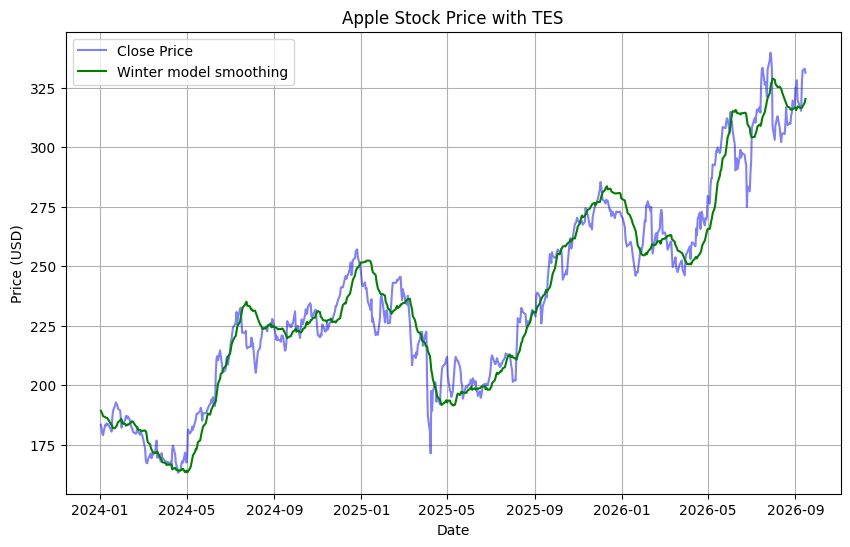

```python
tes_model = ExponentialSmoothing(close_prices, trend = 'add',seasonal = 'add', seasonal_periods = 12). fit(smoothing_level=0.07)
stock_data['TES'] = tes_model.fittedvalues

plt.figure(figsize =(10,6))
plt.plot(stock_data['Close'],label = 'Close Price',color ='blue',alpha = 0.5)
plt.plot(stock_data['TES'],label = 'Winter model smoothing',color ='green')

plt.title('Apple Stock Price with TES')
plt.xlabel('Date')
plt.ylabel('Price (USD)')
plt.legend()
plt.grid()
plt.show()
```

Auto correlation and Partial Auto correlation function

Correlation between x and lagged version of x

For stationary data: ACF decays exponentially or sinosoidally  
Model ACF PACF  
AR Tails off, decays cuts off after lag p  
MA cuts off after q tails off  
ARMA(if non stationary arima) tails off tails off

ACF gives q value  
PACF gives p value

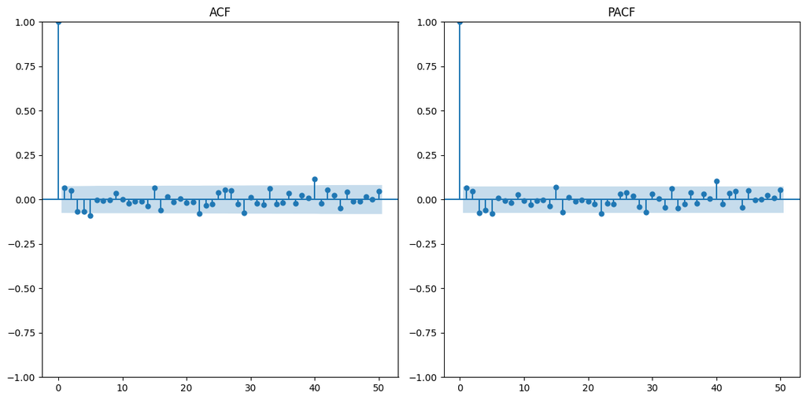

```python
from statsmodels.graphics.tsaplots import plot_acf , plot_pacf
plt.figure(figsize=(12,6))
#acf
plt.subplot(1,2,1)
plot_acf(stock_data['Close'].diff().dropna(),ax=plt.gca(),lags = 50)
plt.title("ACF")
#pacf
plt.subplot(1,2,2)
plot_pacf(stock_data['Close'].diff().dropna(),ax=plt.gca(),lags = 50,method='ywm')
plt.title("PACF")
plt.tight_layout()
plt.show()
```

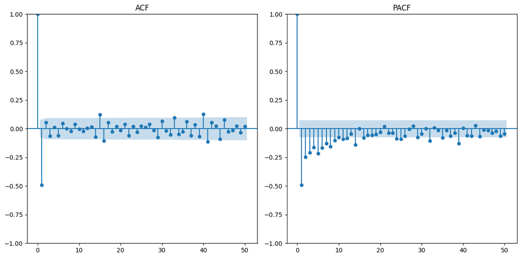

```python
plt.figure(figsize=(12,6))
#acf
plt.subplot(1,2,1)
plot_acf(stock_data['Close'].diff().diff().dropna(),ax=plt.gca(),lags = 50)
plt.title("ACF")
#pacf
plt.subplot(1,2,2)
plot_pacf(stock_data['Close'].diff().diff().dropna(),ax=plt.gca(),lags = 50,method='ywm')
plt.title("PACF")
plt.tight_layout()
plt.show()
```

acf gives q = 1, pacf gives q = 7 , we can use arima model

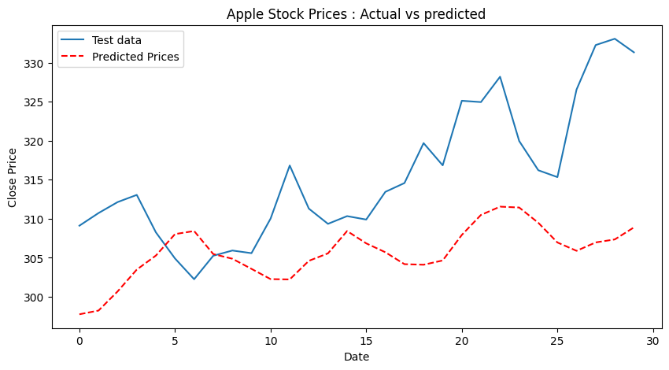

```
RMSE:12.49
MAE:10.34
RMSE:156.0001
MAPE:3.228038222889794
AIC:3522.1589336629086
AIC:3663.8065643015548
```

```python
from statsmodels.tsa.ar_model import AutoReg
apple_price_stationary = stock_data["Close"]
train_data, test_data = apple_price_stationary[:-30], apple_price_stationary[-30:]
train_data = train_data.reset_index(drop=True)
test_data = test_data.reset_index(drop=True)

model = AutoReg(train_data, lags = 30)
model_fit = model.fit()
# Using integer indices based on array length
start_idx = len(train_data)
end_idx = len(train_data) + len(test_data) - 1
prediction = model_fit.predict(start=start_idx, end=end_idx, dynamic=False)
#Plot the actual vs predicted values

#plot the actual vs predicted values
plt.figure(figsize =(10,5))
plt.plot(test_data.index, test_data, label="Test data")
plt.plot(test_data.index,prediction,color='red',linestyle="--",label ="Predicted Prices")
plt.title("Apple Stock Prices : Actual vs predicted")
plt.xlabel("Date")
plt.ylabel('Close Price')
plt.legend()
plt.show()
from sklearn.metrics import mean_absolute_error, mean_squared_error
rmse = round(np.sqrt(mean_squared_error(test_data, prediction)),2)
mae = round(mean_absolute_error(test_data,prediction),2)
mape = np.mean(np.abs((list(test_data.to_numpy().flatten())-prediction.to_numpy().flatten())/list(test_data.to_numpy().flatten())))*100
print(f"RMSE:{rmse}")
print(f"MAE:{mae}")
print(f"RMSE:{rmse**2}")
print(f"MAPE:{mape}")
print(f"AIC:{model_fit.aic}")
print(f"AIC:{model_fit.bic}")
```

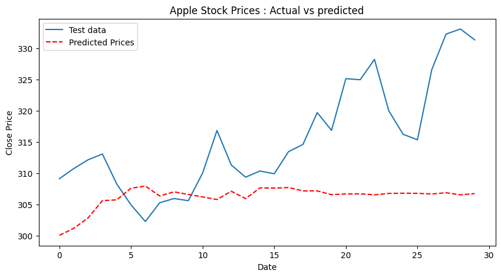

```
RMSE:12.56
MAE:9.97
RMSE:157.7536
MAPE:3.1018403138618575
AIC:3561.4534177701416
AIC:3659.189301432442
```

```python
from statsmodels.tsa.ar_model import AutoReg
apple_price_stationary = stock_data["Close"]
train_data, test_data = apple_price_stationary[:-30], apple_price_stationary[-30:]
train_data = train_data.reset_index(drop=True)
test_data = test_data.reset_index(drop=True)

model = AutoReg(train_data, lags = 20)
model_fit = model.fit()
# Using integer indices based on array length
start_idx = len(train_data)
end_idx = len(train_data) + len(test_data) - 1
prediction = model_fit.predict(start=start_idx, end=end_idx, dynamic=False)
#Plot the actual vs predicted values

#plot the actual vs predicted values
plt.figure(figsize =(10,5))
plt.plot(test_data.index, test_data, label="Test data")
plt.plot(test_data.index,prediction,color='red',linestyle="--",label ="Predicted Prices")
plt.title("Apple Stock Prices : Actual vs predicted")
plt.xlabel("Date")
plt.ylabel('Close Price')
plt.legend()
plt.show()
from sklearn.metrics import mean_absolute_error, mean_squared_error
rmse = round(np.sqrt(mean_squared_error(test_data, prediction)),2)
mae = round(mean_absolute_error(test_data,prediction),2)
mape = np.mean(np.abs((list(test_data.to_numpy().flatten())-prediction.to_numpy().flatten())/list(test_data.to_numpy().flatten())))*100
print(f"RMSE:{rmse}")
print(f"MAE:{mae}")
print(f"RMSE:{rmse**2}")
print(f"MAPE:{mape}")
print(f"AIC:{model_fit.aic}")
print(f"AIC:{model_fit.bic}")
```